# Some Experiments on Adverb Ordering

Michael Hahn

# Ordering Data

To get a numerical measure of an adverb’s order preference, I created a logistic random-effects model predicting, given two adverbs, which one came first in a given corpus occurrence. This model has random intercepts for the two adverbs, and no fixed effects. I constrained the correlation matrix of this model to be [[1,-1],[-1,1]] – that is, the two random intercepts are perfectly anti-correlated, encoding the prior knowledge that the order in which the two adverbs are entered into the model should be irrelevant to predicting the order found in the corpus. The fitted random slopes form an empirical measure of the ordering preference of adverbs: The slope for an adverb will be lower if it tends to appear earlier, and higher if it tends to appear later.

Compared to a simpler measure such as the overall proportion with which an adverb appears before or after another adverb in corpus sentences, this measure has the advantage that it controls for differences in frequency between adverbs.

The resulting measure has this distribution:

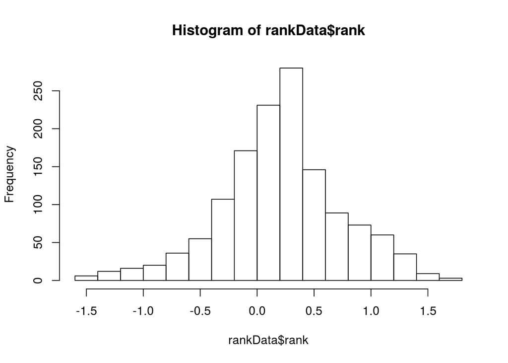

Here are some high-frequency adverbs, ordered by the rank (negative rank means that the adverb tends to occur earlier), with corpus frequencies (only counting occurrences where there is one other adverb):

```
##             adverb        rank frequency
## 754   nevertheless -1.21942672      2168
## 85          anyway -1.21501493      2984
## 1222 unfortunately -1.20646209      5518
## 1177          thus -1.09806920      4846
## 1334           yet -0.89855036      7566
## 594        instead -0.85453446      2525
## 571         indeed -0.79606359      5599
## 1296          well -0.79549074     21752
## 974          sadly -0.77396746      2346
## 524        however -0.74599479     54711
## 862         please -0.71966716      5987
## 1037            so -0.69103593     38327
## 812      otherwise -0.64943262      2635
## 847        perhaps -0.62132971     11406
```

[output cut: 55 more lines]

# Rating Study

I extracted sentences with pre-verbal adverbs from the dependency-parsed Ukwac. Due to automatic parsing, data are noisy, so more work would need to be done for a rigorous experiment.

## First Questionnaire (48)

https://stanford.edu/~mhahn2/experiments/qp1/experiment/48-corpus/order-preference.html

Questions:

1. Does the sentence make sense?
2. Is the speaker saying that …?
3. Does the highlighted word describe whether the speaker thinks that …?
4. Does it describe how the fact that … relates to what was said before?
5. Does it describe the way in which …?
6. Does it describe the speaker's attitude towards the fact that …?

Here are violin diagrams for the responses:

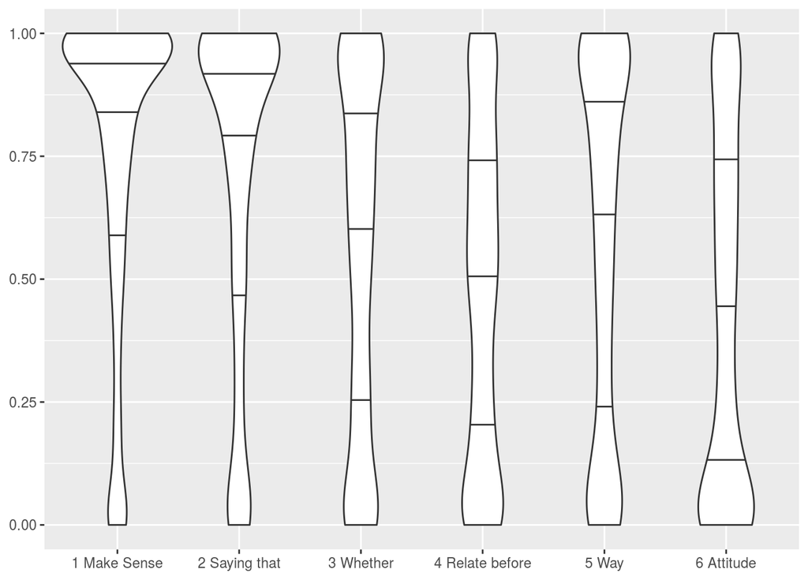

## Second Questionnaire (49)

https://stanford.edu/~mhahn2/experiments/qp1/experiment/49-corpus/order-preference.html

Some of the questions are as in the previous one, some are replaced by new ones:

1. Does the sentence make sense?
2. Is the speaker saying that …?
3. Does the highlighted word comment on the fact that …?
4. Does it describe how the speaker feels about the fact that …?
5. Does it relate the sentence to things that might have been said earlier?
6. Does it describe the way in which …?

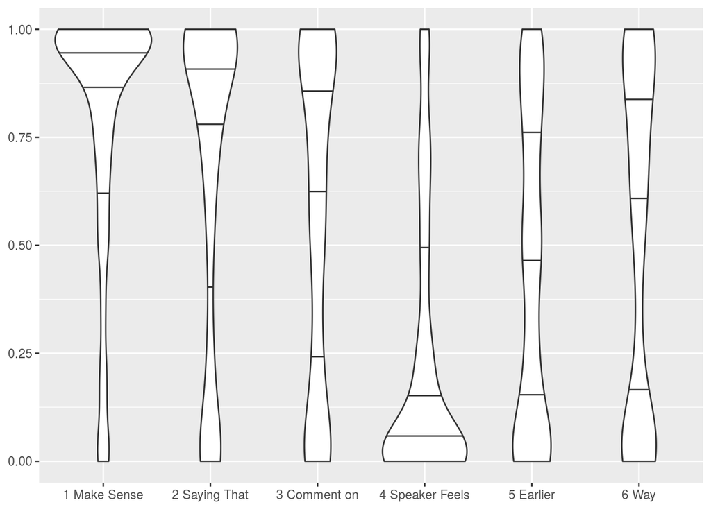

# Questionnaire vs Ordering Data

Here, I’m predicting the answers to each question from the two questionnaires from the adverb’s ordering preference, quantified by ranking adverbs as described above. In each graph, I’m showing a mixed effects model, and a plot of the responses as a function of the ordering preference rank.

## Does the sentence make sense?

This question is just to get an idea of data quality and possibly later weeding out bad data. The responses are somewhat correlated with the ordering rank (t > 3) – not clear to me why this happens:

```
## Linear mixed model fit by REML ['lmerMod']
## Formula: sense ~ rank + (1 | adverb) + (1 | workerid)
##    Data: data
##
## REML criterion at convergence: 583.3
##
## Scaled residuals:
##     Min      1Q  Median      3Q     Max
## -3.4476 -0.2632  0.2491  0.5732  2.6350
##
## Random effects:
##  Groups   Name        Variance Std.Dev.
##  adverb   (Intercept) 0.019999 0.14142
##  workerid (Intercept) 0.008083 0.08991
##  Residual             0.065668 0.25626
## Number of obs: 1674, groups:  adverb, 313; workerid, 84
##
## Fixed effects:
##             Estimate Std. Error t value
## (Intercept)  0.74956    0.01516   49.43
## rank         0.05153    0.01488    3.46
##
## Correlation of Fixed Effects:
##      (Intr)
## rank -0.303
```

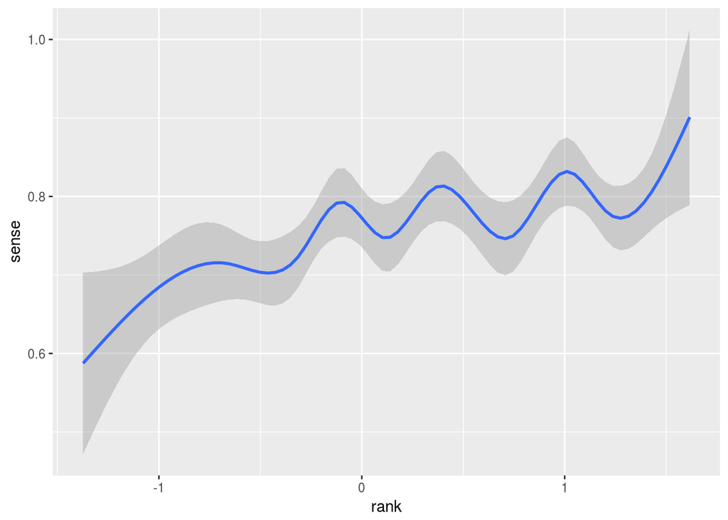

## Is the speaker saying that …?

The effect here (t > 4) could point to adverbs restricting/denying/… the truth (e.g., possibly, not) tend to come earlier.

```
## Linear mixed model fit by REML ['lmerMod']
## Formula: that ~ rank + (1 | adverb) + (1 | workerid)
##    Data: data
##
## REML criterion at convergence: 978.6
##
## Scaled residuals:
##     Min      1Q  Median      3Q     Max
## -2.7967 -0.5126  0.2404  0.6194  2.1652
##
## Random effects:
##  Groups   Name        Variance Std.Dev.
##  adverb   (Intercept) 0.035621 0.18873
##  workerid (Intercept) 0.008291 0.09105
##  Residual             0.080213 0.28322
## Number of obs: 1674, groups:  adverb, 313; workerid, 84
##
## Fixed effects:
##             Estimate Std. Error t value
## (Intercept)  0.65483    0.01750   37.42
## rank         0.09045    0.01850    4.89
##
## Correlation of Fixed Effects:
##      (Intr)
## rank -0.322
```

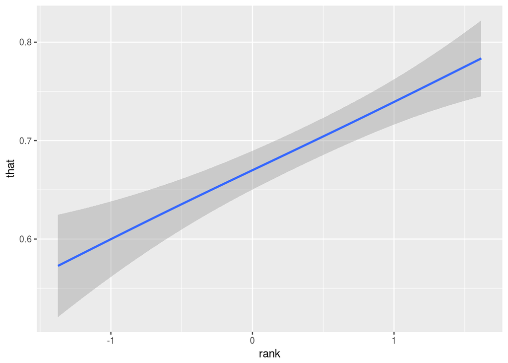

## Does the highlighted word describe whether the speaker thinks that …?

Interpretation of effect (t > 3) not clear to me.

```
## Linear mixed model fit by REML ['lmerMod']
## Formula: whether ~ rank + (1 | adverb) + (1 | workerid)
##    Data: data
##
## REML criterion at convergence: 696.5
##
## Scaled residuals:
##     Min      1Q  Median      3Q     Max
## -2.6263 -0.6886  0.1316  0.7020  2.6093
##
## Random effects:
##  Groups   Name        Variance Std.Dev.
##  adverb   (Intercept) 0.01552  0.1246
##  workerid (Intercept) 0.02534  0.1592
##  Residual             0.08570  0.2927
## Number of obs: 1136, groups:  adverb, 303; workerid, 57
##
## Fixed effects:
##             Estimate Std. Error t value
## (Intercept)  0.52423    0.02474  21.186
## rank         0.06524    0.01669   3.909
##
## Correlation of Fixed Effects:
##      (Intr)
## rank -0.223
```

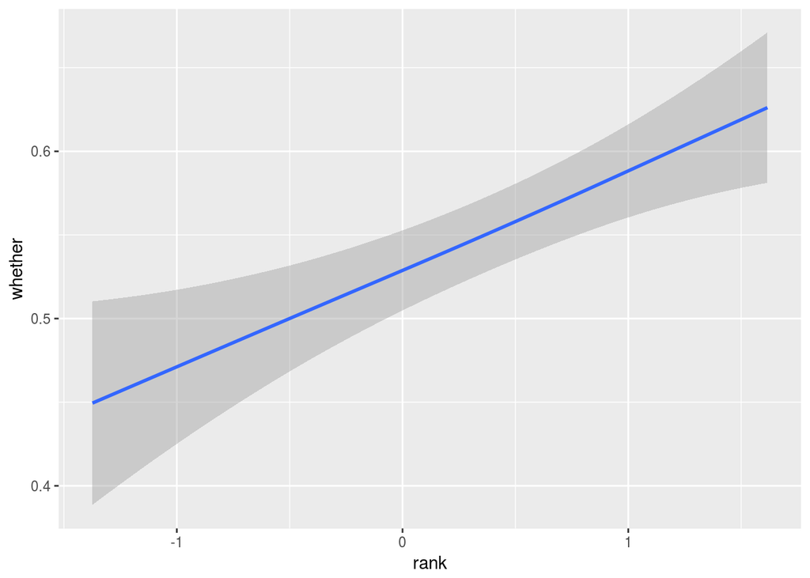

## Does it describe how the fact that … relates to what was said before?

I would expect such adverbs to come earlier, but there is no significant effect.

```
## Linear mixed model fit by REML ['lmerMod']
## Formula: before ~ rank + (1 | adverb) + (1 | workerid)
##    Data: data
##
## REML criterion at convergence: 569
##
## Scaled residuals:
##      Min       1Q   Median       3Q      Max
## -2.55903 -0.67724 -0.00118  0.69460  2.75136
##
## Random effects:
##  Groups   Name        Variance Std.Dev.
##  adverb   (Intercept) 0.005376 0.07332
##  workerid (Intercept) 0.027300 0.16523
##  Residual             0.081852 0.28610
## Number of obs: 1136, groups:  adverb, 303; workerid, 57
##
## Fixed effects:
##             Estimate Std. Error t value
## (Intercept)  0.48014    0.02441  19.669
## rank        -0.01700    0.01399  -1.216
##
## Correlation of Fixed Effects:
##      (Intr)
## rank -0.194
```

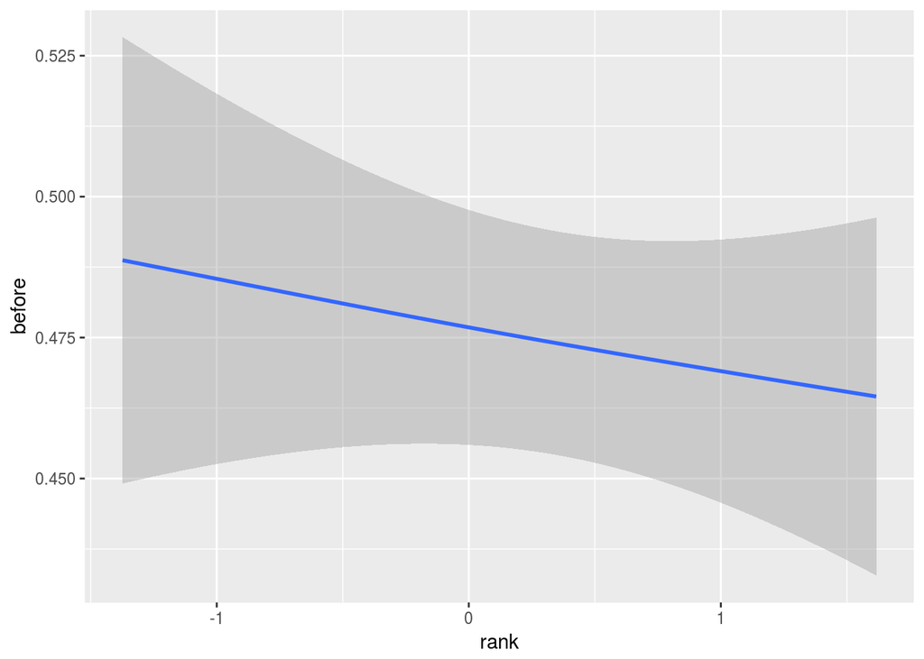

## Does it describe the way in which …?

This is the strongest effect (both coefficient and t value) in these analyses, so I think it can be trusted: Adverbs that describe the action come later.

```
## Linear mixed model fit by REML ['lmerMod']
## Formula: way ~ rank + (1 | adverb) + (1 | workerid)
##    Data: data
##
## REML criterion at convergence: 1168.1
##
## Scaled residuals:
##     Min      1Q  Median      3Q     Max
## -2.6847 -0.7707  0.1545  0.7043  2.4728
##
## Random effects:
##  Groups   Name        Variance Std.Dev.
##  adverb   (Intercept) 0.01355  0.1164
##  workerid (Intercept) 0.01988  0.1410
##  Residual             0.09802  0.3131
## Number of obs: 1674, groups:  adverb, 313; workerid, 84
##
## Fixed effects:
##             Estimate Std. Error t value
## (Intercept)  0.50025    0.01922   26.03
## rank         0.15914    0.01490   10.68
##
## Correlation of Fixed Effects:
##      (Intr)
## rank -0.245
```

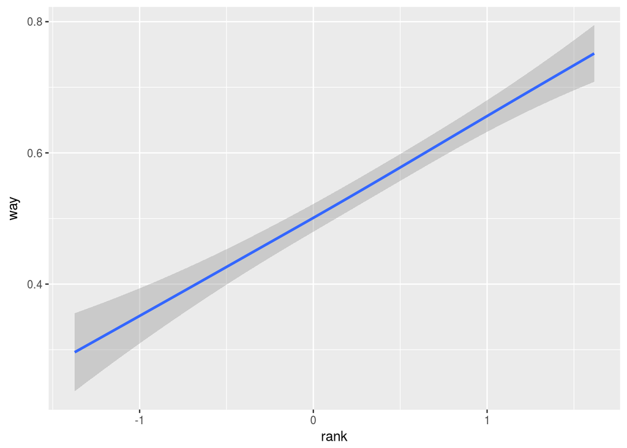

## Does it describe the speaker's attitude towards the fact that …?

While the effect in the linear model doesn’t have strong evidence, the U-shaped curve is replicated in the `feelings’-question below. Maybe it has to do with clause-level vs VP-level adverbs – I’d expect there to be attitudinal adverbs in both groups. More work is needed to figure out whether this points to something real.

```
## Linear mixed model fit by REML ['lmerMod']
## Formula: attitude ~ rank + (1 | adverb) + (1 | workerid)
##    Data: data
##
## REML criterion at convergence: 563.6
##
## Scaled residuals:
##      Min       1Q   Median       3Q      Max
## -2.76379 -0.63427 -0.03246  0.64561  2.83970
##
## Random effects:
##  Groups   Name        Variance Std.Dev.
##  adverb   (Intercept) 0.01112  0.1055
##  workerid (Intercept) 0.04332  0.2081
##  Residual             0.07545  0.2747
## Number of obs: 1136, groups:  adverb, 303; workerid, 57
##
## Fixed effects:
##             Estimate Std. Error t value
## (Intercept)  0.41183    0.02994  13.754
## rank         0.03186    0.01508   2.113
##
## Correlation of Fixed Effects:
##      (Intr)
## rank -0.167
```

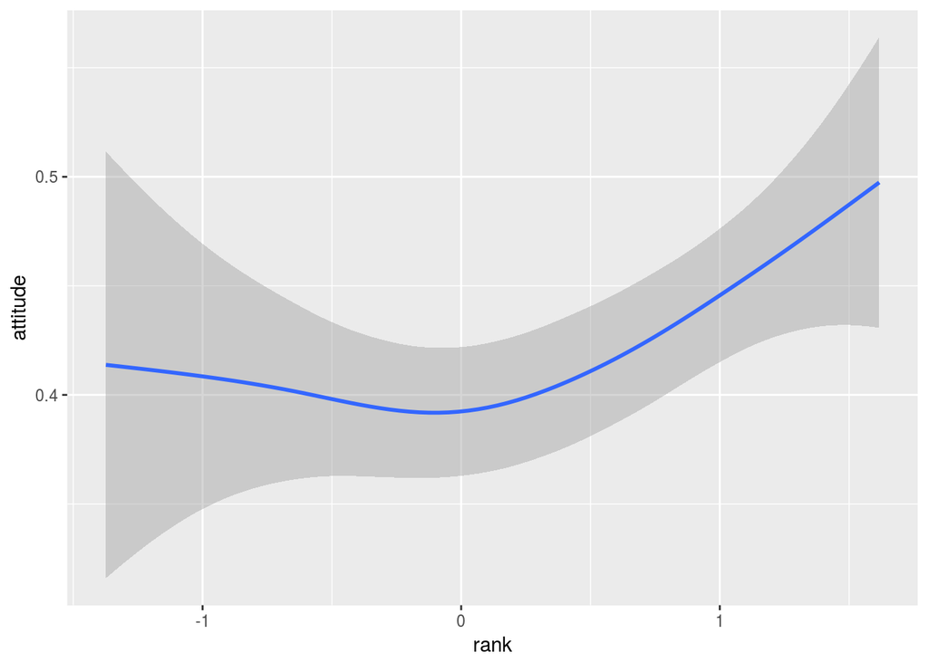

## Does the highlighted word comment on the fact that …?

I had expected such adverbs to come earlier (e.g., `fortunately’). Not clear to me how this result can be interpreted.

```
## Linear mixed model fit by REML ['lmerMod']
## Formula: comment ~ rank + (1 | adverb) + (1 | workerid)
##    Data: data
##
## REML criterion at convergence: 393.3
##
## Scaled residuals:
##     Min      1Q  Median      3Q     Max
## -2.6707 -0.7045  0.1708  0.6575  2.0476
##
## Random effects:
##  Groups   Name        Variance Std.Dev.
##  adverb   (Intercept) 0.03480  0.1865
##  workerid (Intercept) 0.02102  0.1450
##  Residual             0.08326  0.2886
## Number of obs: 538, groups:  adverb, 245; workerid, 27
##
## Fixed effects:
##             Estimate Std. Error t value
## (Intercept)  0.52494    0.03394  15.466
## rank         0.14162    0.02528   5.602
##
## Correlation of Fixed Effects:
##      (Intr)
## rank -0.219
```

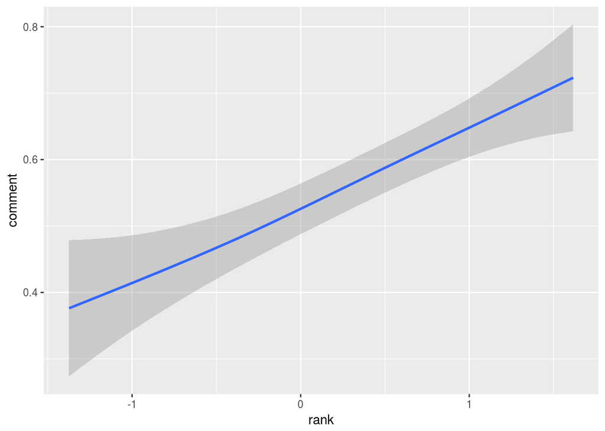

## Does it describe how the speaker feels about the fact that …?

see `attitudes’ section

```
## Linear mixed model fit by REML ['lmerMod']
## Formula: feel ~ rank + (1 | adverb) + (1 | workerid)
##    Data: data
##
## REML criterion at convergence: 197.6
##
## Scaled residuals:
##     Min      1Q  Median      3Q     Max
## -1.9026 -0.5592 -0.2559  0.1413  2.9275
##
## Random effects:
##  Groups   Name        Variance Std.Dev.
##  adverb   (Intercept) 0.01771  0.1331
##  workerid (Intercept) 0.01461  0.1209
##  Residual             0.06203  0.2490
## Number of obs: 538, groups:  adverb, 245; workerid, 27
##
## Fixed effects:
##              Estimate Std. Error t value
## (Intercept)  0.229814   0.027863   8.248
## rank        -0.003086   0.020118  -0.153
##
## Correlation of Fixed Effects:
##      (Intr)
## rank -0.213
```

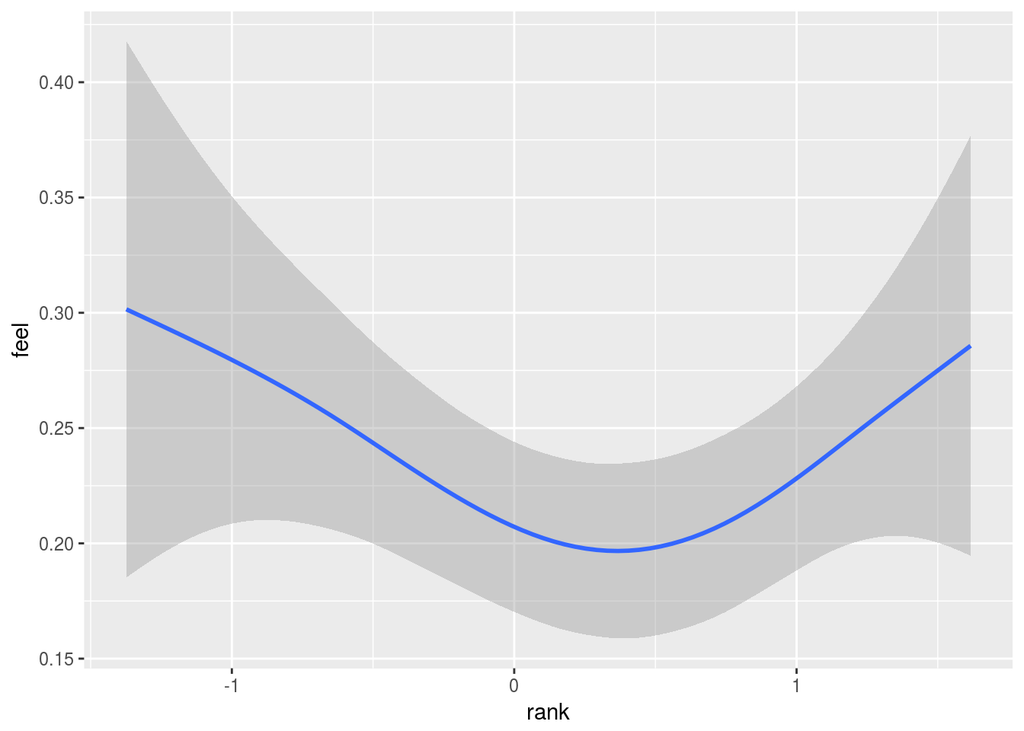

## Does it relate the sentence to things that might have been said earlier?

As for the similar previous question, no evidence for an effect.

```
## Linear mixed model fit by REML ['lmerMod']
## Formula: earlier ~ rank + (1 | adverb) + (1 | workerid)
##    Data: data
##
## REML criterion at convergence: 263.6
##
## Scaled residuals:
##     Min      1Q  Median      3Q     Max
## -2.2181 -0.6713 -0.1562  0.5583  3.1510
##
## Random effects:
##  Groups   Name        Variance Std.Dev.
##  adverb   (Intercept) 0.005561 0.07457
##  workerid (Intercept) 0.049687 0.22290
##  Residual             0.077479 0.27835
## Number of obs: 538, groups:  adverb, 245; workerid, 27
##
## Fixed effects:
##             Estimate Std. Error t value
## (Intercept)  0.43868    0.04521   9.704
## rank        -0.02783    0.01888  -1.474
##
## Correlation of Fixed Effects:
##      (Intr)
## rank -0.123
```

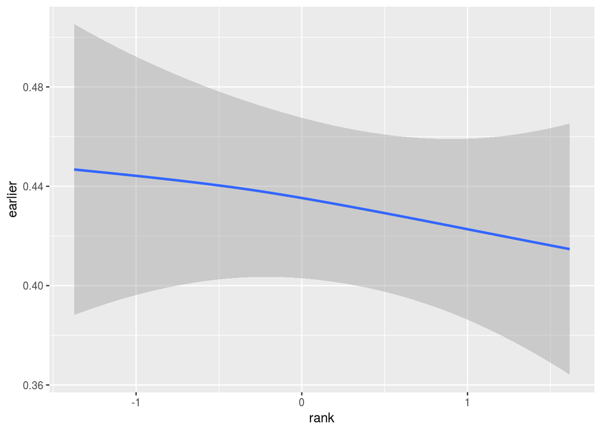

# Subjectivity (43, 47)

https://stanford.edu/~mhahn2/experiments/qp1/experiment/43-subjectivity/order-preference.html

https://stanford.edu/~mhahn2/experiments/qp1/experiment/47-subjectivity/order-preference.html

This experiment is identical to the original Scontras et al. task collecting subjectivity ratings, but with adverbs.

Here, I test whether order preferences predict subjectivity ratings. At this point, there is no indication that subjectivity ratings correlate with order preferences:

```
## Linear mixed model fit by REML ['lmerMod']
## Formula: response ~ rank + (1 | predicate) + (1 | workerid)
##    Data: dataSubj
##
## REML criterion at convergence: 398.8
##
## Scaled residuals:
##      Min       1Q   Median       3Q      Max
## -2.58517 -0.76760  0.07282  0.76381  2.68478
##
## Random effects:
##  Groups    Name        Variance Std.Dev.
##  predicate (Intercept) 0.015454 0.12432
##  workerid  (Intercept) 0.007486 0.08652
##  Residual              0.067250 0.25933
## Number of obs: 1216, groups:  predicate, 329; workerid, 44
##
## Fixed effects:
##             Estimate Std. Error t value
## (Intercept)  0.50999    0.01800  28.329
## rank         0.02681    0.01657   1.618
##
## Correlation of Fixed Effects:
##      (Intr)
## rank -0.092
```

# Mutual Information

I quantified pointwise mutual information between adverbs and verbs by counting joint occurrences, disregarding any other words (context, the other adverb, and intervening material).

Mutual Information is predictive of distance to the verb, and even more of logarithmic distance:

```
## Linear mixed model fit by REML ['lmerMod']
## Formula: Distance ~ mi + (1 | Adverb) + (1 | Head)
##    Data: mi
##
## REML criterion at convergence: 144531
##
## Scaled residuals:
##    Min     1Q Median     3Q    Max
## -9.455 -0.292 -0.114  0.043 52.114
##
## Random effects:
##  Groups   Name        Variance Std.Dev.
##  Head     (Intercept)  1.835   1.355
##  Adverb   (Intercept)  3.280   1.811
##  Residual             13.001   3.606
## Number of obs: 26374, groups:  Head, 2046; Adverb, 1168
##
## Fixed effects:
##             Estimate Std. Error t value
## (Intercept) -2.55298    0.29842  -8.555
## mi          -0.31200    0.01865 -16.730
##
## Correlation of Fixed Effects:
##    (Intr)
## mi 0.952
```

```
## Linear mixed model fit by maximum likelihood  ['lmerMod']
## Formula: log.Distance ~ mi + (1 | Adverb) + (1 | Head)
##    Data: mi
##
##      AIC      BIC   logLik deviance df.resid
##  49357.6  49398.5 -24673.8  49347.6    26369
##
## Scaled residuals:
##     Min      1Q  Median      3Q     Max
## -3.0653 -0.5673 -0.2002  0.2759  7.0054
##
## Random effects:
##  Groups   Name        Variance Std.Dev.
##  Head     (Intercept) 0.04258  0.2064
##  Adverb   (Intercept) 0.11139  0.3338
##  Residual             0.35171  0.5931
## Number of obs: 26374, groups:  Head, 2046; Adverb, 1168
##
## Fixed effects:
##              Estimate Std. Error t value
## (Intercept) -1.073498   0.049308  -21.77
## mi          -0.095887   0.003074  -31.19
##
## Correlation of Fixed Effects:
##    (Intr)
## mi 0.948
```

Comparing to a baseline model with only random effects:

```
## Data: mi
## Models:
## m0: log.Distance ~ (1 | Adverb) + (1 | Head)
## m: log.Distance ~ mi + (1 | Adverb) + (1 | Head)
##    Df   AIC   BIC logLik deviance  Chisq Chi Df Pr(>Chisq)
## m0  4 50311 50343 -25151    50303
## m   5 49358 49399 -24674    49348 954.96      1  < 2.2e-16 ***
## ---
## Signif. codes:  0 '***' 0.001 '**' 0.01 '*' 0.05 '.' 0.1 ' ' 1
```

Plotting plain distance over mutual information (for now, mutual information measure is correct only up to an additive costant, I just calculated log count of pair - log count of verb - log count of adverb. Would need to take into account log corpus size to get the actual Mutual Information):

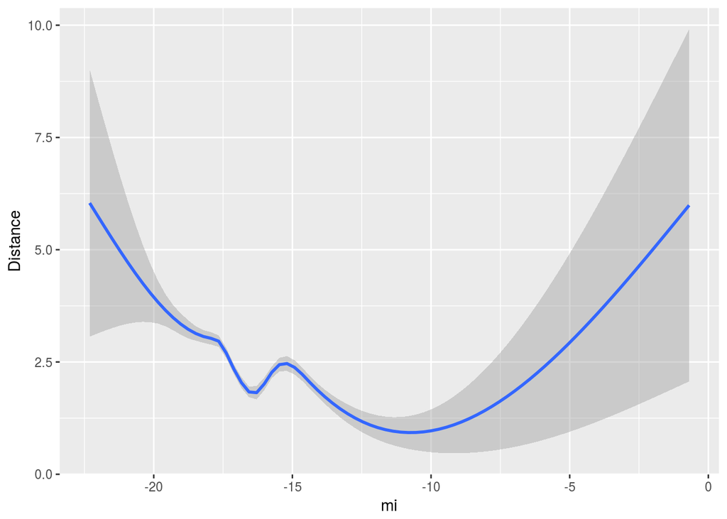

Plotting mutual information over plain distance:

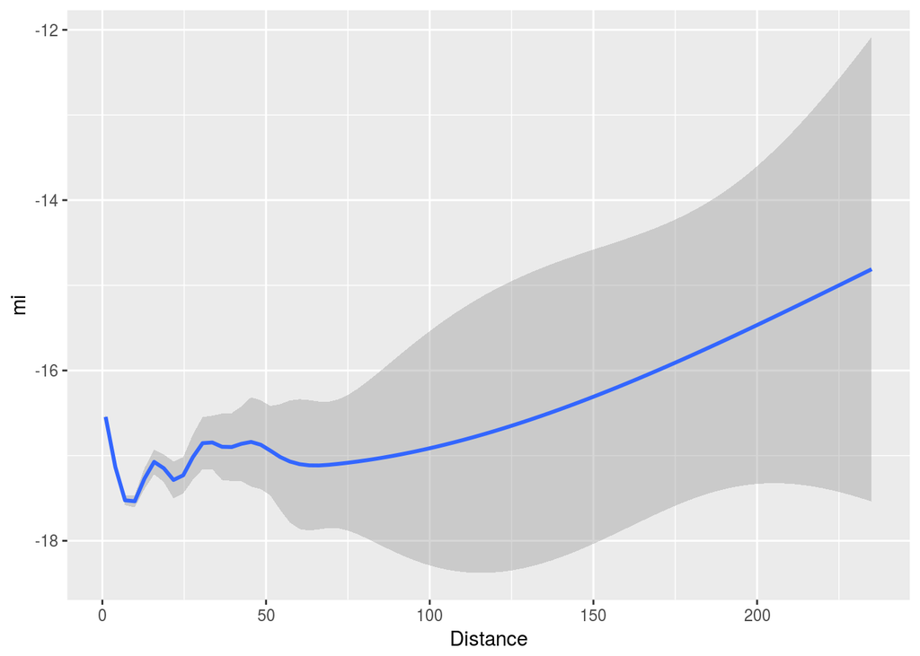

Plotting log distance over mutual information:

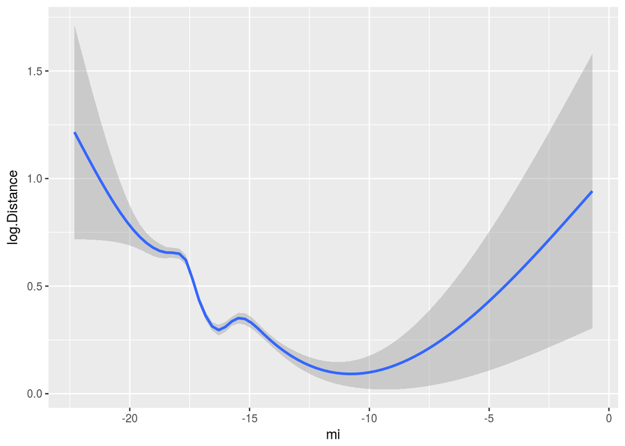

Plotting mutual information over log distance:

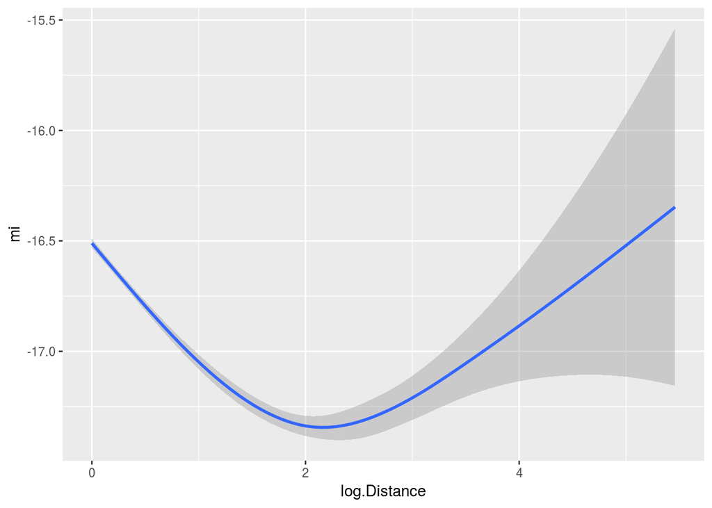

# Aggregate Data (Mutual Information, Mean Distance, Ordering Preference)

Correlation between average PMI and mean log distance:

```
##
##  Pearson's product-moment correlation
##
## data:  agg4$log.Distance and agg4$mi
## t = -5.4391, df = 318, p-value = 1.07e-07
## alternative hypothesis: true correlation is not equal to 0
## 95 percent confidence interval:
##  -0.3889382 -0.1881160
## sample estimates:
##        cor
## -0.2917389
```

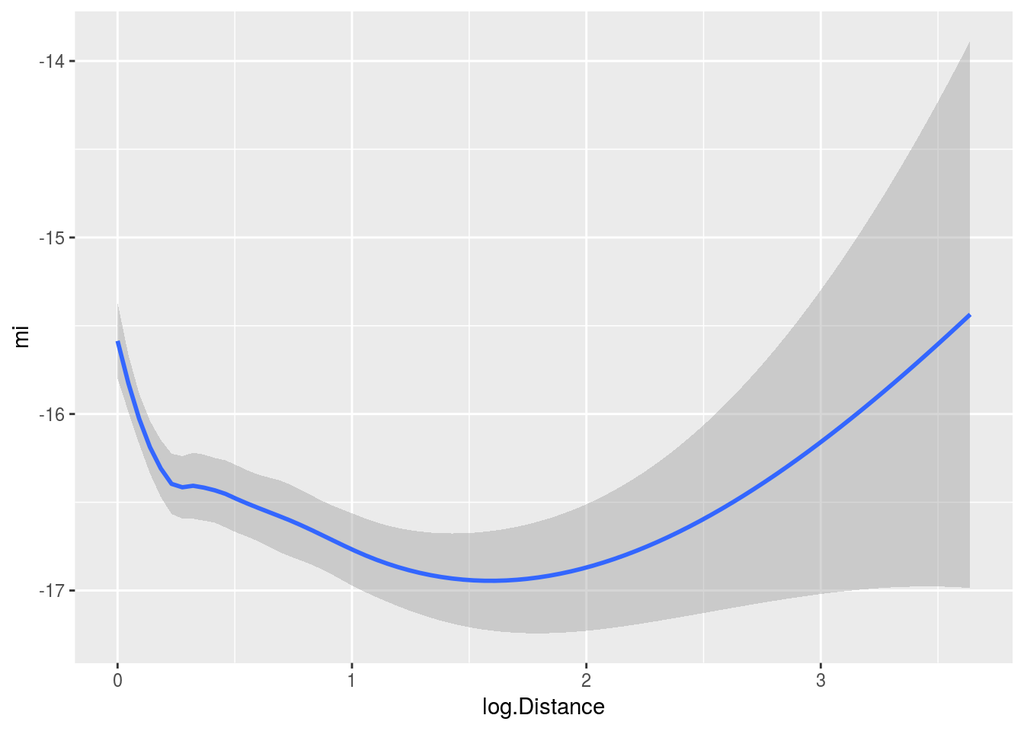

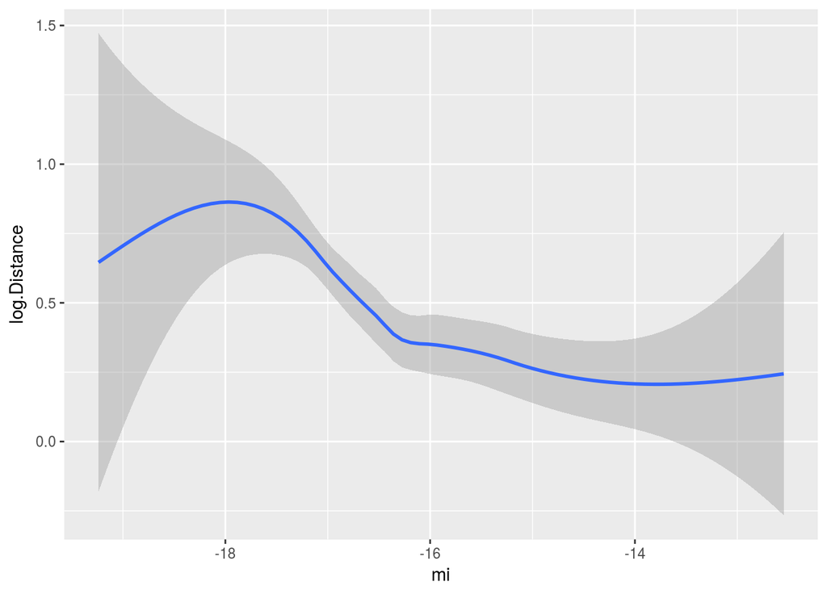

Log Distance vs Ordering rank:

```
##
##  Pearson's product-moment correlation
##
## data:  agg4$log.Distance and agg4$rank
## t = -11.947, df = 318, p-value < 2.2e-16
## alternative hypothesis: true correlation is not equal to 0
## 95 percent confidence interval:
##  -0.6279127 -0.4759984
## sample estimates:
##        cor
## -0.5565908
```

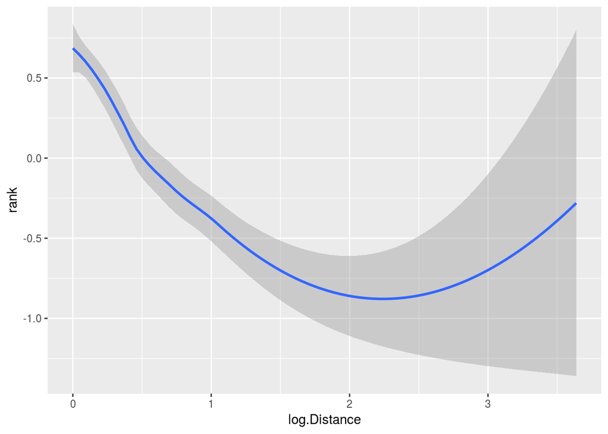

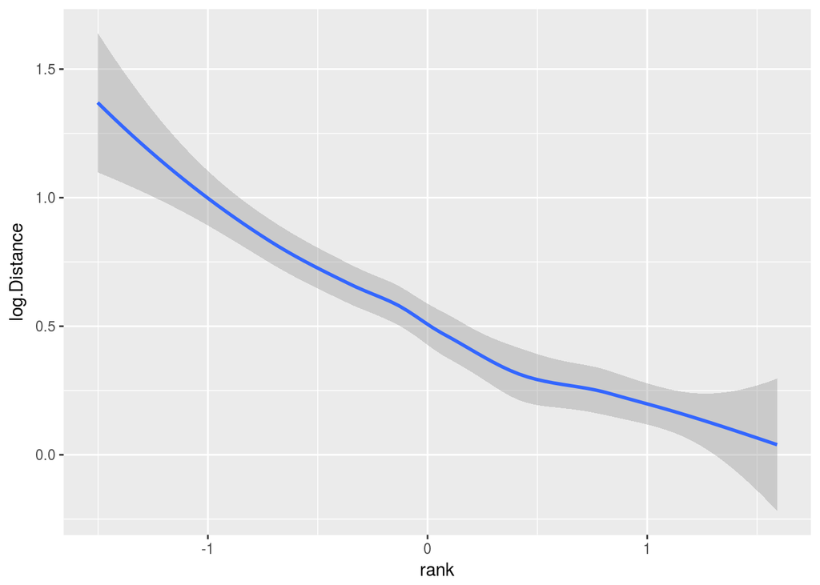

Mutual Information vs Ordering rank:

```
##
##  Pearson's product-moment correlation
##
## data:  agg4$mi and agg4$rank
## t = 6.7183, df = 318, p-value = 8.495e-11
## alternative hypothesis: true correlation is not equal to 0
## 95 percent confidence interval:
##  0.2526787 0.4449912
## sample estimates:
##       cor
## 0.3525517
```

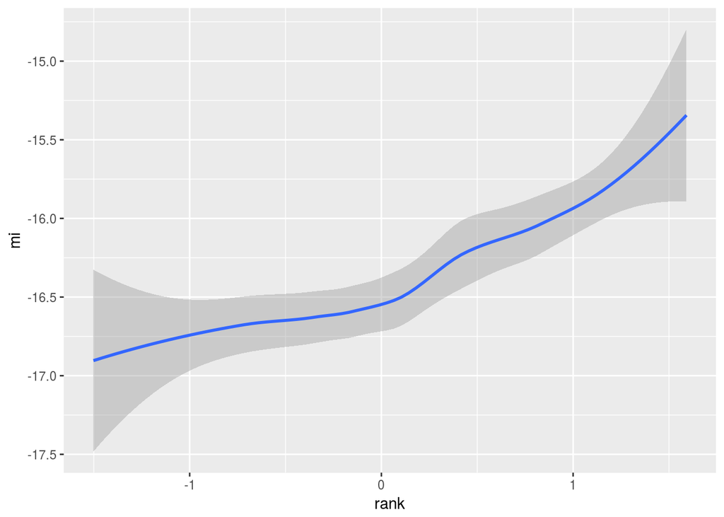

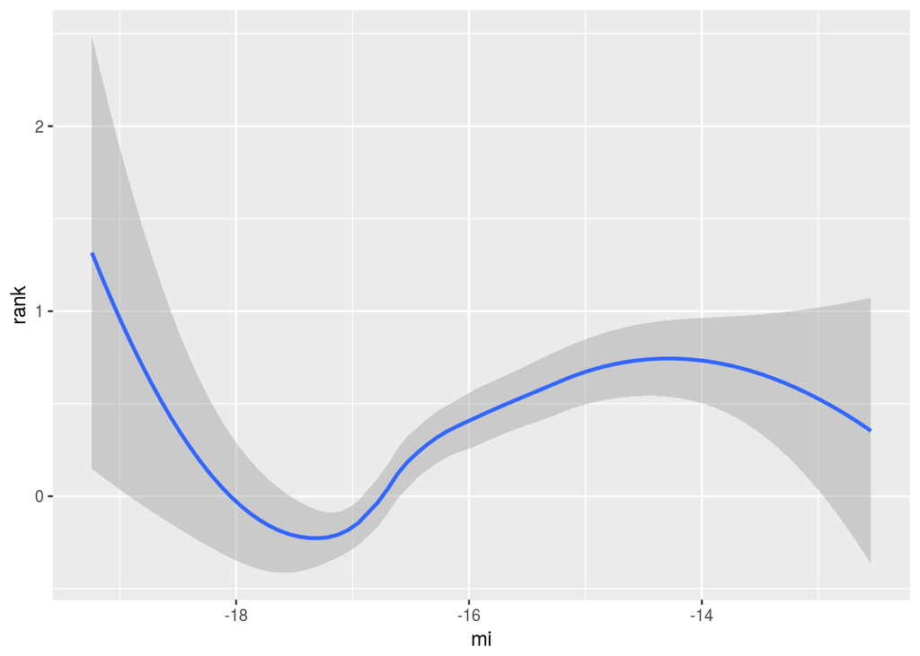

These data show that mean mutual information as a property of the adverb is quite predictive of the ordering preference.

# Mutual Information and Questionnaire Data

Here I’m predicting questionnaire data (per trial and worker) from mean mutual information. The only reasonably strong effect is the one for `Does it describe the way in which …?’.

## Does the sentence make sense?

```
## Linear mixed model fit by REML ['lmerMod']
## Formula: sense ~ mi + (1 | adverb) + (1 | workerid)
##    Data: data
##
## REML criterion at convergence: 426.4
##
## Scaled residuals:
##     Min      1Q  Median      3Q     Max
## -3.2619 -0.2529  0.2696  0.5746  2.4172
##
## Random effects:
##  Groups   Name        Variance Std.Dev.
##  adverb   (Intercept) 0.016779 0.12954
##  workerid (Intercept) 0.007343 0.08569
##  Residual             0.066890 0.25863
## Number of obs: 1215, groups:  adverb, 221; workerid, 84
##
## Fixed effects:
##             Estimate Std. Error t value
## (Intercept)  1.08194    0.23023   4.699
## mi           0.01851    0.01399   1.323
##
## Correlation of Fixed Effects:
##    (Intr)
## mi 0.998
```

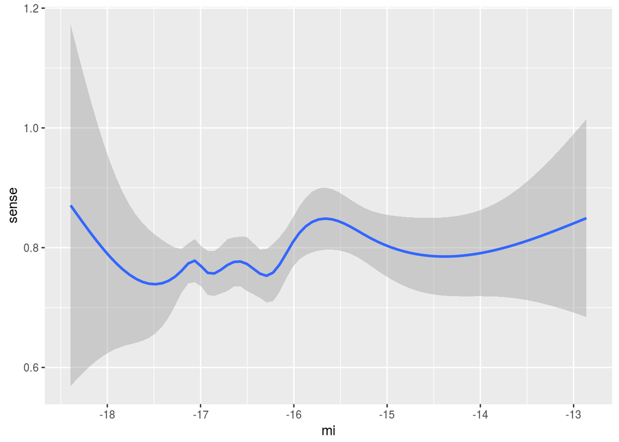

## Is the speaker saying that …?

```
## Linear mixed model fit by REML ['lmerMod']
## Formula: that ~ mi + (1 | adverb) + (1 | workerid)
##    Data: data
##
## REML criterion at convergence: 763.2
##
## Scaled residuals:
##     Min      1Q  Median      3Q     Max
## -2.8263 -0.5591  0.2584  0.6174  2.1061
##
## Random effects:
##  Groups   Name        Variance Std.Dev.
##  adverb   (Intercept) 0.038762 0.19688
##  workerid (Intercept) 0.007948 0.08915
##  Residual             0.083128 0.28832
## Number of obs: 1215, groups:  adverb, 221; workerid, 84
##
## Fixed effects:
##             Estimate Std. Error t value
## (Intercept)  0.99229    0.30740   3.228
## mi           0.01899    0.01870   1.016
##
## Correlation of Fixed Effects:
##    (Intr)
## mi 0.998
```

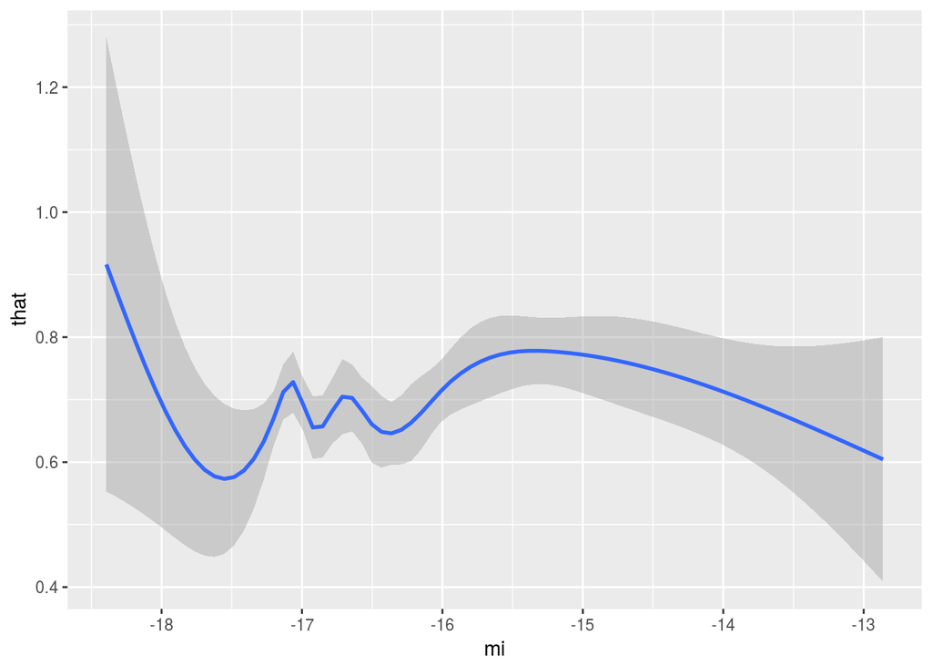

## Does the highlighted word describe whether the speaker thinks that …?

```
## Linear mixed model fit by REML ['lmerMod']
## Formula: whether ~ mi + (1 | adverb) + (1 | workerid)
##    Data: data
##
## REML criterion at convergence: 534.8
##
## Scaled residuals:
##     Min      1Q  Median      3Q     Max
## -2.5999 -0.6750  0.1111  0.6706  2.5381
##
## Random effects:
##  Groups   Name        Variance Std.Dev.
##  adverb   (Intercept) 0.01652  0.1285
##  workerid (Intercept) 0.02653  0.1629
##  Residual             0.08598  0.2932
## Number of obs: 833, groups:  adverb, 215; workerid, 57
##
## Fixed effects:
##             Estimate Std. Error t value
## (Intercept)  1.00992    0.26869   3.759
## mi           0.02845    0.01630   1.746
##
## Correlation of Fixed Effects:
##    (Intr)
## mi 0.995
```

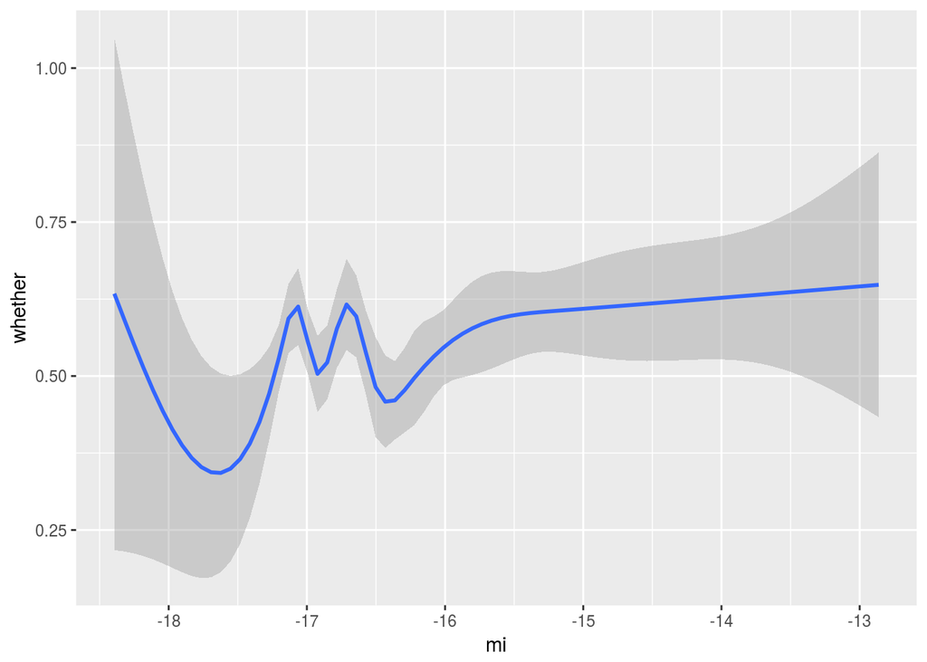

## Does it describe how the fact that … relates to what was said before?

```
## Linear mixed model fit by REML ['lmerMod']
## Formula: before ~ mi + (1 | adverb) + (1 | workerid)
##    Data: data
##
## REML criterion at convergence: 460.6
##
## Scaled residuals:
##      Min       1Q   Median       3Q      Max
## -2.49108 -0.66457 -0.01727  0.71127  2.71123
##
## Random effects:
##  Groups   Name        Variance Std.Dev.
##  adverb   (Intercept) 0.004991 0.07065
##  workerid (Intercept) 0.025823 0.16070
##  Residual             0.085342 0.29213
## Number of obs: 833, groups:  adverb, 215; workerid, 57
##
## Fixed effects:
##             Estimate Std. Error t value
## (Intercept)  0.17963    0.22641   0.793
## mi          -0.01836    0.01370  -1.339
##
## Correlation of Fixed Effects:
##    (Intr)
## mi 0.994
```

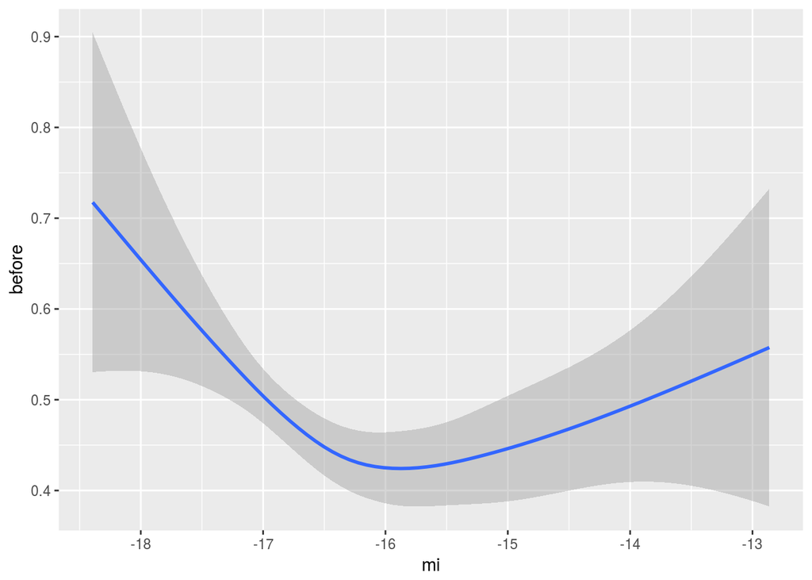

## Does it describe the way in which …?

This is the strongest effect.

```
## Linear mixed model fit by REML ['lmerMod']
## Formula: way ~ mi + (1 | adverb) + (1 | workerid)
##    Data: data
##
## REML criterion at convergence: 936.1
##
## Scaled residuals:
##     Min      1Q  Median      3Q     Max
## -2.6234 -0.7969  0.1042  0.7282  2.3021
##
## Random effects:
##  Groups   Name        Variance Std.Dev.
##  adverb   (Intercept) 0.02186  0.1479
##  workerid (Intercept) 0.02238  0.1496
##  Residual             0.09977  0.3159
## Number of obs: 1215, groups:  adverb, 221; workerid, 84
##
## Fixed effects:
##             Estimate Std. Error t value
## (Intercept)  1.63132    0.27257   5.985
## mi           0.06700    0.01655   4.049
##
## Correlation of Fixed Effects:
##    (Intr)
## mi 0.997
```

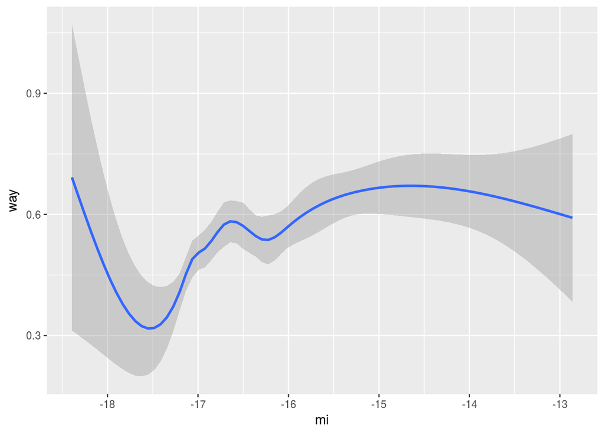

## Does it describe the speaker's attitude towards the fact that …?

```
## Linear mixed model fit by REML ['lmerMod']
## Formula: attitude ~ mi + (1 | adverb) + (1 | workerid)
##    Data: data
##
## REML criterion at convergence: 416.4
##
## Scaled residuals:
##      Min       1Q   Median       3Q      Max
## -2.67395 -0.63118 -0.08708  0.65430  2.89501
##
## Random effects:
##  Groups   Name        Variance Std.Dev.
##  adverb   (Intercept) 0.006681 0.08174
##  workerid (Intercept) 0.044668 0.21135
##  Residual             0.076362 0.27634
## Number of obs: 833, groups:  adverb, 215; workerid, 57
##
## Fixed effects:
##             Estimate Std. Error t value
## (Intercept)  0.87350    0.22481   3.885
## mi           0.02791    0.01357   2.058
##
## Correlation of Fixed Effects:
##    (Intr)
## mi 0.991
```

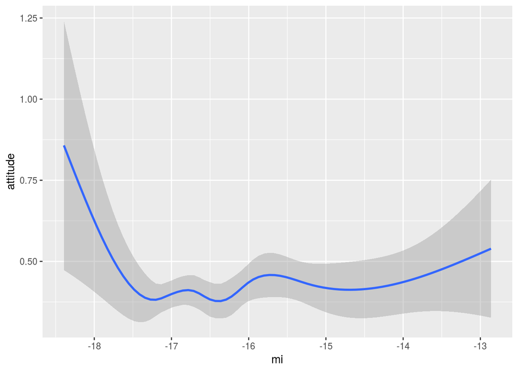

## Does the highlighted word comment on the fact that …?

```
## Linear mixed model fit by REML ['lmerMod']
## Formula: comment ~ mi + (1 | adverb) + (1 | workerid)
##    Data: data
##
## REML criterion at convergence: 313.9
##
## Scaled residuals:
##     Min      1Q  Median      3Q     Max
## -1.9861 -0.7363  0.1874  0.6501  1.7298
##
## Random effects:
##  Groups   Name        Variance Std.Dev.
##  adverb   (Intercept) 0.04714  0.2171
##  workerid (Intercept) 0.02312  0.1520
##  Residual             0.08383  0.2895
## Number of obs: 382, groups:  adverb, 170; workerid, 27
##
## Fixed effects:
##             Estimate Std. Error t value
## (Intercept)  1.16115    0.50042    2.32
## mi           0.03666    0.03030    1.21
##
## Correlation of Fixed Effects:
##    (Intr)
## mi 0.997
```

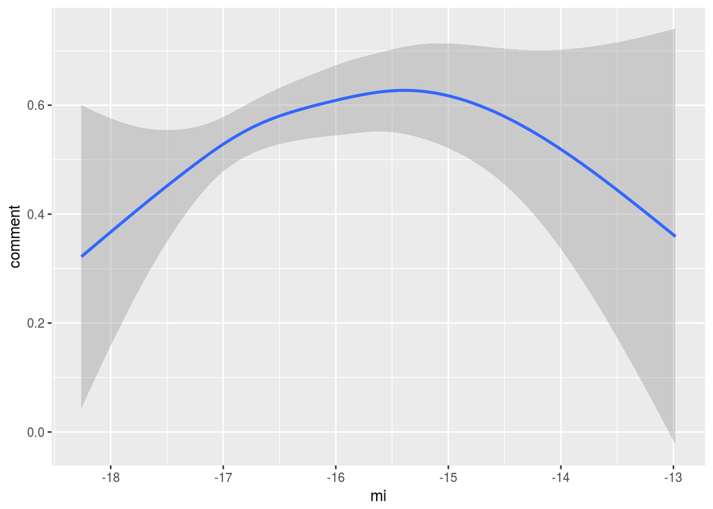

## Does it describe how the speaker feels about the fact that …?

```
## Linear mixed model fit by REML ['lmerMod']
## Formula: feel ~ mi + (1 | adverb) + (1 | workerid)
##    Data: data
##
## REML criterion at convergence: 139.7
##
## Scaled residuals:
##     Min      1Q  Median      3Q     Max
## -1.6462 -0.5386 -0.2580  0.1573  2.7530
##
## Random effects:
##  Groups   Name        Variance Std.Dev.
##  adverb   (Intercept) 0.01940  0.1393
##  workerid (Intercept) 0.01206  0.1098
##  Residual             0.06000  0.2450
## Number of obs: 382, groups:  adverb, 170; workerid, 27
##
## Fixed effects:
##              Estimate Std. Error t value
## (Intercept)  0.159956   0.370241   0.432
## mi          -0.003976   0.022416  -0.177
##
## Correlation of Fixed Effects:
##    (Intr)
## mi 0.997
```

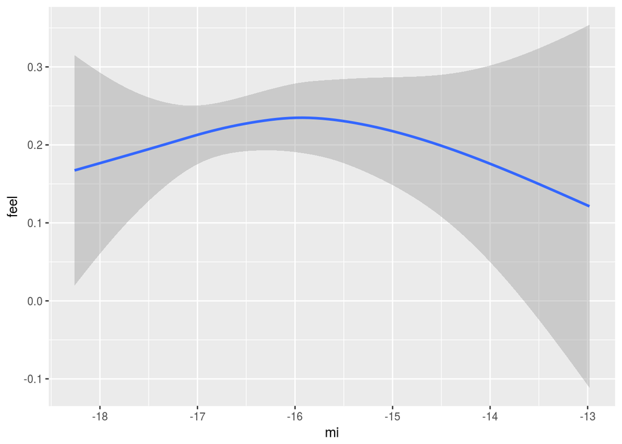

## Does it relate the sentence to things that might have been said earlier?

```
## Linear mixed model fit by REML ['lmerMod']
## Formula: earlier ~ mi + (1 | adverb) + (1 | workerid)
##    Data: data
##
## REML criterion at convergence: 208
##
## Scaled residuals:
##     Min      1Q  Median      3Q     Max
## -2.3577 -0.6572 -0.1561  0.6339  3.3033
##
## Random effects:
##  Groups   Name        Variance Std.Dev.
##  adverb   (Intercept) 0.00000  0.0000
##  workerid (Intercept) 0.05173  0.2274
##  Residual             0.08417  0.2901
## Number of obs: 382, groups:  adverb, 170; workerid, 27
##
## Fixed effects:
##             Estimate Std. Error t value
## (Intercept) -0.26372    0.33161  -0.795
## mi          -0.04337    0.01993  -2.176
##
## Correlation of Fixed Effects:
##    (Intr)
## mi 0.990
```

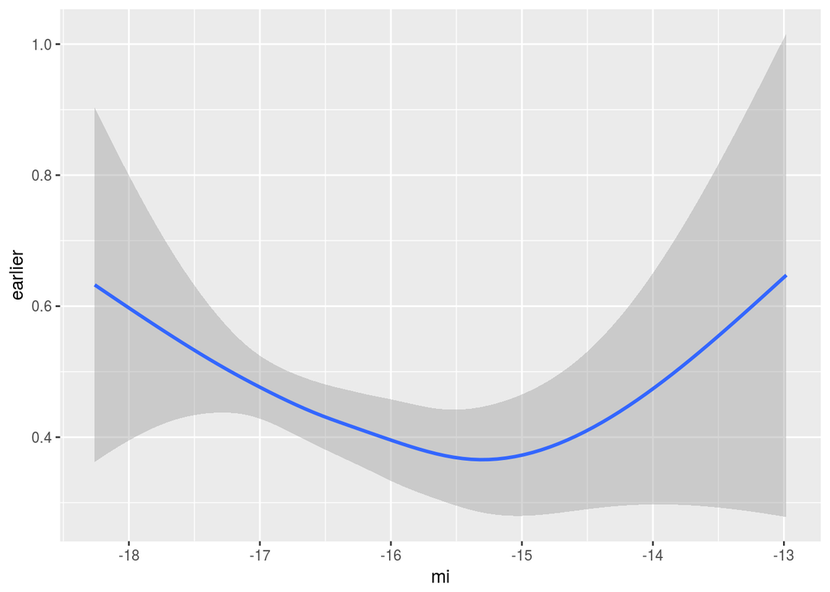

# Predicting Order from MI and Questionnaire Responses

Here, I’m predicting order preferences measured by the ranks from MI and questionnaire responses. All measures are averaged, so no random effects here. Among all models predicting rank from average MI + averaged responses, the one with the lowest p-value is:

```
##
## Call:
## lm(formula = rank ~ mi + way + before, data = agg)
##
## Residuals:
##      Min       1Q   Median       3Q      Max
## -1.79932 -0.41863 -0.01267  0.43861  1.56824
##
## Coefficients:
##             Estimate Std. Error t value Pr(>|t|)
## (Intercept)  3.09208    0.81339   3.801 0.000188 ***
## mi           0.20088    0.04868   4.127 5.29e-05 ***
## way          1.37893    0.18827   7.324 5.00e-12 ***
## before      -0.58381    0.20691  -2.822 0.005236 **
## ---
## Signif. codes:  0 '***' 0.001 '**' 0.01 '*' 0.05 '.' 0.1 ' ' 1
##
## Residual standard error: 0.6209 on 211 degrees of freedom
##   (1135 observations deleted due to missingness)
## Multiple R-squared:  0.305,  Adjusted R-squared:  0.2951
## F-statistic: 30.86 on 3 and 211 DF,  p-value: < 2.2e-16
```

Here I’m predicting mean log distance from the head. The model with lowest p-value is:

```
##
## Call:
## lm(formula = log.Distance ~ mi + way + before + whether + feel +
##     comment + that, data = agg)
##
## Residuals:
##      Min       1Q   Median       3Q      Max
## -0.76720 -0.21628 -0.04849  0.13348  1.05935
##
## Coefficients:
##             Estimate Std. Error t value Pr(>|t|)
## (Intercept) -1.47167    0.63249  -2.327  0.02126 *
## mi          -0.12493    0.03754  -3.328  0.00109 **
## way         -0.25741    0.15034  -1.712  0.08885 .
## before       0.43175    0.16083   2.684  0.00805 **
## whether     -0.47752    0.14780  -3.231  0.00151 **
## feel         0.25847    0.11216   2.304  0.02251 *
## comment     -0.28833    0.10251  -2.813  0.00554 **
## that         0.22303    0.12997   1.716  0.08814 .
## ---
## Signif. codes:  0 '***' 0.001 '**' 0.01 '*' 0.05 '.' 0.1 ' ' 1
##
## Residual standard error: 0.3387 on 156 degrees of freedom
##   (1186 observations deleted due to missingness)
## Multiple R-squared:  0.3002, Adjusted R-squared:  0.2688
## F-statistic: 9.561 on 7 and 156 DF,  p-value: 7.332e-10
```

# Conclusion

Adverb ordering is predicted to some extent by MI and the responses to the `describes the way in which …’ question.